fossil

# Ensemble networks for tumour classes, dug back up.

We rebuilt the lost Matlab method from the paper and reran it on the seven Kent Ridge datasets. Of 19 results we tried, 8 came back exactly, 8 agree, 1 partly agree and 2 differ.

See every result

## Install cfsenn

Python package

```
pip install "git+https://github.com/jeonglab-bcm/fossil#subdirectory=PMC522806/package"
```

Python 3.10 or later, with NumPy and SciPy.

[README](https://github.com/jeonglab-bcm/fossil/blob/main/PMC522806/package/README.md) [Tutorial](https://github.com/jeonglab-bcm/fossil/blob/main/PMC522806/package/tutorial/TUTORIAL.md)

## Fig. 3

Fig. 3. Test-set accuracy on ALL-AML, lung and prostate: Tan and Gilbert's bagged decision trees and the best cited method (quoted, kept as published) and the paper's method (redrawn from our run).

Agreeson review

Published

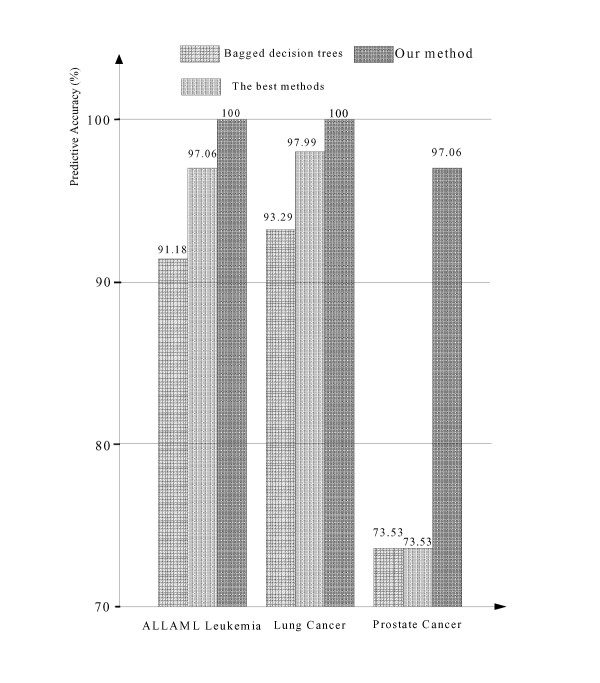

Our run

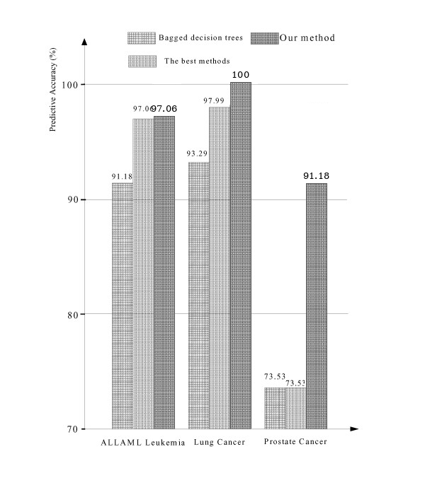

**Fig. 3, 'Our method' bars (test sets)**

1 of 3 values, Agrees

The 'Our method' bars are Table 2's test accuracies (see table2.test): lung comes back; prostate is two samples short as found and back to 33 of 34 with per-array scaling; ALL-AML is one sample short. The published bars are drawn at their labels (within 0.25 points).

## Fig. 4

Fig. 4. Accuracy without test sets: the best cited method (kept as published) and the paper's method (redrawn from our run): DLBCL on Cho and Won's 22/25 split, ovarian by 10-fold CV, colon by LOOCV.

Agreeson review

Published

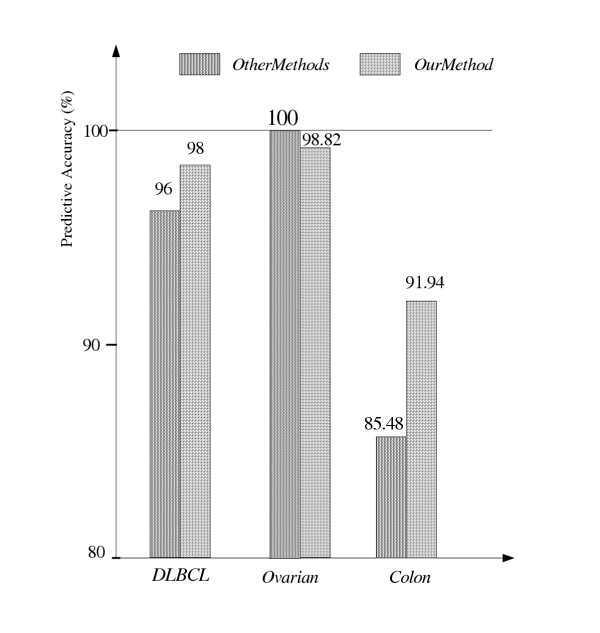

Our run

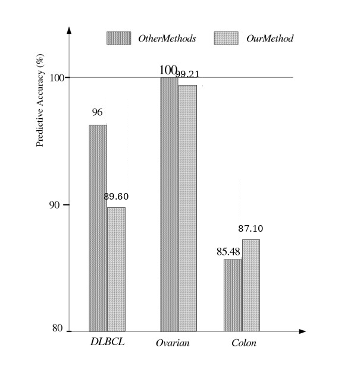

**Fig. 4, 'OurMethod' bars (DLBCL 22/25 split, ovarian 10-fold, colon LOOCV)**

0 of 3 values, Agrees

DLBCL on 22/25 splits: 89.6% over 20 random splits (72% to 100%; one split gives 25 of 25), against 98%; Cho and Won's samples are not listed, and 98% is not a whole count of 25. Ovarian and colon bars as in Table 3. The published ovarian bar is drawn at 99.25%, 0.43 above its label 98.82% and close to the LOOCV 99.21% (the other bars of this figure sit up to 0.36 off their labels).

## Tables 2 and 3

The paper's accuracies next to our run (seed 0, first fold assignment), with the correct count. The quoted rows come from other papers and are not rerun.

| Table 2 | ALL-AML Paper | ALL-AML Ours | Lung Paper | Lung Ours | Prostate Paper | Prostate Ours |
| --- | --- | --- | --- | --- | --- | --- |
| Bagged decision trees | 91.18% quoted |  | 93.29% quoted |  | 73.53% quoted |  |
| The best methods | 97.06% quoted |  | 97.99% quoted |  | 73.53% quoted |  |
| Our methods (test set) | 100% | **97.06%** 33/34 | 100% | **100.00%** 149/149 | 97.06% | **91.18%** 31/34 |
| LOOCV on training samples | 100% | **97.37%** 37/38 | 100% | **100.00%** 32/32 | 96.08% | **93.14%** 95/102 |

| Table 3 | DLBCL Paper | DLBCL Ours | Ovarian Paper | Ovarian Ours | Colon Paper | Colon Ours |
| --- | --- | --- | --- | --- | --- | --- |
| LOOCV, our method | 97.87% | **97.87%** 46/47 | 99.21% | **99.60%** 252/253 | 91.94% | **87.10%** 54/62 |
| 10-fold CV, our method | 95.74% | **95.74%** 45/47 | 98.82% | **99.21%** 251/253 | 90.32% | **87.10%** 54/62 |

How much a rerun moves:

- ALL-AML test set, seeds 0 to 4: 33/34, 32/34, 32/34, 32/34, 33/34
- Lung test set, seeds 0 to 4: 149/149, 149/149, 148/149, 148/149, 149/149
- Prostate test set, seeds 0 to 4: 31/34, 30/34, 31/34, 27/34, 31/34
- MLL test set, seeds 0 to 4: 15/15, 15/15, 15/15, 15/15, 15/15
- DLBCL 10-fold CV, three fold assignments: 45/47, 46/47, 45/47
- Ovarian 10-fold CV, three fold assignments: 251/253, 251/253, 250/253
- Colon 10-fold CV, three fold assignments: 54/62, 54/62, 53/62
- DLBCL, 20 random 22/25 splits (11 + 11 training samples): mean 89.6%; correct per split 18, 20, 21, 21, 22, 22, 22, 22, 22, 23, 23, 23, 23, 23, 23, 23, 24, 24, 24, 25 of 25

## Every result

Each result of the paper, with our value and the verdict check_results.py computes from them. Accuracies are counts of samples; one sample moves a small test set by several points.

Result

Verdict

Measure

Why

Table 1, the seven datasets (genes, training and test samples per class)

Exact

32 of 32 values

- ALL-AML: genes: paper 7129, ours **7129**
- ALL-AML: training samples: paper 38, ours **38**
- ALL-AML: training classes (ALL:AML): paper 27:11, ours **27:11**
- ALL-AML: test samples: paper 34, ours **34**
- ALL-AML: test classes (ALL:AML): paper 20:14, ours **20:14**
- Lung: genes: paper 12533, ours **12533**
- Lung: training samples: paper 32, ours **32**
- Lung: training classes (Mesothelioma:ADCA): paper 16:16, ours **16:16**
- Lung: test samples: paper 149, ours **149**
- Lung: test classes (Mesothelioma:ADCA): paper 15:134, ours **15:134**
- Prostate: genes: paper 12600, ours **12600**
- Prostate: training samples: paper 102, ours **102**
- Prostate: training classes (Tumor:Normal): paper 52:50, ours **52:50**
- Prostate: test samples: paper 34, ours **34**
- Prostate: test classes (Tumor:Normal): paper 25:9, ours **25:9**
- DLBCL: genes: paper 4026, ours **4026**
- DLBCL: training samples: paper 47, ours **47**
- DLBCL: training classes (germinal:activated): paper 24:23, ours **24:23**
- DLBCL: test samples: paper 0, ours **0**
- Ovarian: genes: paper 15154, ours **15154**
- Ovarian: training samples: paper 253, ours **253**
- Ovarian: training classes (Normal:Cancer): paper 91:162, ours **91:162**
- Ovarian: test samples: paper 0, ours **0**
- Colon: genes: paper 2000, ours **2000**
- Colon: training samples: paper 62, ours **62**
- Colon: training classes (negative:positive): paper 40:22, ours **40:22**
- Colon: test samples: paper 0, ours **0**
- MLL: genes: paper 12582, ours **12582**
- MLL: training samples: paper 57, ours **57**
- MLL: training classes (ALL:MLL:AML): paper 20:17:20, ours **20:17:20**
- MLL: test samples: paper 15, ours **15**
- MLL: test classes (ALL:MLL:AML): paper 4:3:8, ours **4:3:8**

Fig. 1 (flow chart)

Not attempted

A flow chart of the method; there is nothing to recompute.

Fig. 2 (the three networks)

Not attempted

A diagram of the three networks; there is nothing to recompute.

Table 2, our methods: test-set accuracy (ALL-AML, lung, prostate)

Agreeson review

1 of 3 values

- ALL-AML test accuracy, % (33 of 34 correct): paper 100, ours **97.06**
- Lung test accuracy, % (149 of 149 correct): paper 100, ours **100**
- Prostate test accuracy, % (31 of 34 correct): paper 97.06, ours **91.18**

Lung comes back (149 of 149). Prostate: 31 of 34 against 33; scaling each array to the same mean intensity, a step the paper does not mention, gives exactly 33 of 34 on all five seeds, so the gap is likely how the test experiment, about 12 times brighter than the training arrays, was handled. ALL-AML: 33 of 34 against 34; the same test sample (31st in the file) is wrong in every seed and every hypothesis test (only the AdaBoost control gets it right, missing another).

Table 2, LOOCV on the training samples

Agreeson review

1 of 3 values

- ALL-AML LOOCV on the training samples, % (37 of 38 correct): paper 100, ours **97.37**
- Lung LOOCV on the training samples, % (32 of 32 correct): paper 100, ours **100**
- Prostate LOOCV on the training samples, % (95 of 102 correct): paper 96.08, ours **93.14**

Lung comes back (32 of 32). ALL-AML 37 of 38 against 38 (training sample 29 is wrong in both runs we made), prostate 95 of 102 against 98. Weight decay 0.1 gains one prostate sample (96); no other setting we tried moves either.

Table 2, bagged decision trees and the best methods (quoted)

Not attempted

Accuracies quoted from Tan and Gilbert (2003) and other papers, not results of this paper. They stay as published in Fig. 3.

Fig. 3, 'Our method' bars (test sets)

Agreeson review

1 of 3 values

- ALL-AML 'Our method' bar, %: paper 100, ours **97.06**
- Lung 'Our method' bar, %: paper 100, ours **100**
- Prostate 'Our method' bar, %: paper 97.06, ours **91.18**

The 'Our method' bars are Table 2's test accuracies (see table2.test): lung comes back; prostate is two samples short as found and back to 33 of 34 with per-array scaling; ALL-AML is one sample short. The published bars are drawn at their labels (within 0.25 points).

Table 3, LOOCV (DLBCL, ovarian, colon)

Agreeson review

1 of 3 values

- DLBCL LOOCV, % (46 of 47 correct): paper 97.87, ours **97.87**
- Ovarian LOOCV, % (252 of 253 correct): paper 99.21, ours **99.60**
- Colon LOOCV, % (54 of 62 correct): paper 91.94, ours **87.10**

DLBCL comes back (46 of 47). Ovarian 252 of 253 against 251, one sample better. Colon 54 of 62 against 57; none of eight variants moves colon above 54.

Table 3, 10-fold CV (DLBCL, ovarian, colon)

Agreeson review

1 of 3 values

- DLBCL 10-fold CV, % (45 of 47 correct): paper 95.74, ours **95.74**
- Ovarian 10-fold CV, % (251 of 253 correct): paper 98.82, ours **99.21**
- Colon 10-fold CV, % (54 of 62 correct): paper 90.32, ours **87.10**

DLBCL comes back (45 of 47). Ovarian 251 of 253 against the printed 98.82%, which is not a whole count of 253 (250/253 = 98.81%, our third fold assignment). Colon 54 of 62 against 56 (53 to 54 over three fold assignments).

Table 3, other methods (quoted)

Not attempted

Accuracies quoted from Dettling and Buhlmann (colon, 85.48%) and Liu, Li and Wong (ovarian, 100%), not results of this paper.

Fig. 4, 'OurMethod' bars (DLBCL 22/25 split, ovarian 10-fold, colon LOOCV)

Agreeson review

0 of 3 values

- DLBCL 'OurMethod' bar, Cho and Won's 22/25 split, % (mean of 20 random splits): paper 98, ours **90**
- Ovarian 'OurMethod' bar (10-fold CV), %: paper 98.82, ours **99.21**
- Colon 'OurMethod' bar (LOOCV), %: paper 91.94, ours **87.10**

DLBCL on 22/25 splits: 89.6% over 20 random splits (72% to 100%; one split gives 25 of 25), against 98%; Cho and Won's samples are not listed, and 98% is not a whole count of 25. Ovarian and colon bars as in Table 3. The published ovarian bar is drawn at 99.25%, 0.43 above its label 98.82% and close to the LOOCV 99.21% (the other bars of this figure sit up to 0.36 off their labels).

Text: MLL, 15 of 15 test samples correct

Exact

1 of 1 values

- MLL test samples classified correctly (of 15): paper 15, ours **15**

Text: 75 features in all

Exact

1 of 1 values

- features per ensemble member (30 rank-sum genes + 15 PCs + 30 clustered genes): paper 75, ours **75**

Claims recomputed from the paper's own tables

Agrees

Text and Fig. 3: better than bagged decision trees on all three test sets

Exact

3 of 3 values

- ALL-AML: our test accuracy above Tan and Gilbert's bagged trees (91.18%): paper yes, ours **yes**
- Lung: our test accuracy above Tan and Gilbert's bagged trees (93.29%): paper yes, ours **yes**
- Prostate: our test accuracy above Tan and Gilbert's bagged trees (73.53%): paper yes, ours **yes**

Text: better than the best cited method on all three test sets

Partly agrees

2 of 3 values

- ALL-AML: our test accuracy above the best cited method (97.06%): paper yes, ours **no**
- Lung: our test accuracy above the best cited method (97.99%): paper yes, ours **yes**
- Prostate: our test accuracy above the best cited method (73.53%): paper yes, ours **yes**

Our ALL-AML test accuracy (33 of 34) equals the best cited method's 97.06% instead of beating it; lung and prostate hold. Follows table2.test.

Text: prostate LOOCV a little lower than its test accuracy

Differs

0 of 1 values

- Prostate: LOOCV on the training samples a little lower than the test accuracy: paper yes, ours **no**

Our prostate LOOCV (93.14%) is above our test accuracy as found (91.18%). With per-array scaling the test accuracy is 97.06% on all five seeds, above our LOOCV, the order the paper reports: the claim turns on the test-set scaling (see table2.test).

Text: colon LOOCV better than Dettling and Buhlmann's boosting (85.48%)

Exact

1 of 1 values

- Colon: our LOOCV above Dettling and Buhlmann's 85.48%: paper yes, ours **yes**

Text: DLBCL on the 22/25 split better than Cho and Won's 96%

Differs

0 of 1 values

- DLBCL: our accuracy on 22/25 splits above Cho and Won's 96%: paper yes, ours **no**

Our mean over 20 random 22/25 splits is 89.6%, below Cho and Won's 96%; see fig4.

Discussion: random genes in place of the selected features classify worse

Exact

1 of 1 values

- random genes in place of the selected features: fewer correct than ours over the five runs (281 against 313 of 326): paper yes, ours **yes**

Discussion: a single network on all the same features classifies worse

Exact

1 of 1 values

- one network on all 75 features, no ensemble: fewer correct than ours over the five runs (310 against 313 of 326): paper yes, ours **yes**

Discussion and Methods: AdaBoost in place of bagging classifies worse

Exact

1 of 1 values

- AdaBoost in place of bagging: fewer correct than ours over the five runs (305 against 313 of 326): paper yes, ours **yes**

Python package cfsenn and its tutorial

Agrees

The main claim holds in part: our ensemble beats the bagged trees on all three test sets and each Discussion control classifies worse, but it only ties the best cited method on ALL-AML, its prostate LOOCV is not below its test accuracy, and it falls short of Cho and Won's DLBCL split; the causes are one ALL-AML test sample that every seed and hypothesis test misses, the unscaled prostate test arrays and the unlisted 22/25 split.

## What came back

**Table 1**

All seven datasets have the paper's genes and samples, class by class.

**Lung and MLL**

Every test sample right: 149 of 149 and 15 of 15, on every seed for MLL.

**DLBCL**

46 of 47 by LOOCV and 45 of 47 by 10-fold CV, as printed.

**The method**

cfsenn, a Python package with an executed tutorial.

## What stayed buried

- The authors' Matlab code and how they trained the networks.
- How the genes were clustered for the third feature set.
- The samples of Cho and Won's DLBCL split.
- Why one ALL-AML test sample and three colon samples stay wrong for us.

The main claim holds in part: our ensemble beats the bagged trees on all three test sets and each Discussion control classifies worse, but it only ties the best cited method on ALL-AML, its prostate LOOCV is not below its test accuracy, and it falls short of Cho and Won's DLBCL split; the causes are one ALL-AML test sample that every seed and hypothesis test misses, the unscaled prostate test arrays and the unlisted 22/25 split.

## What we matched

The datasets came back whole from a mirror of the lost Kent Ridge repository. Where our counts differ, they differ by one to three samples.

**ALL-AML test**

33 of 34 against 34

**Prostate test, as found**

31 of 34 against 33

**Ovarian LOOCV**

252 of 253 against 251

**Colon LOOCV**

54 of 62 against 57

## The session

The reproduction was done by an AI agent, Claude Code, in one session. Every prompt, reply and tool call of it is published.

**Wall clock**

21.4 h

first message to last, waits included

**Human prompts**

31

messages typed by a person

**Tool calls**

298

29 of them in subagents

**Tokens**

99.0 M

every request, subagents included

Read the session [The raw files](https://github.com/jeonglab-bcm/fossil/tree/main/PMC522806/session)